# assingment07

Jinli Wu & Xiyu Zhang

4/8/2022

```r
library(tidyverse)
library(tidymodels)
library(lubridate)
library(themis)
library(vip)
library(glmnet)
library(ranger)
library(kknn)
library(yardstick)
library(tune)
library(workflows)
library(recipes)
library(parsnip)
library(rsample)
```

```r
# use this url to download the data directly into R
df <- read_csv("https://data.cityofnewyork.us/api/views/43nn-pn8j/rows.csv")
# clean names with janitor
sampled_df <- df %>%
  janitor::clean_names()

# create an inspection year variable
sampled_df <- sampled_df %>%
  mutate(inspection_date = mdy(inspection_date)) %>%
  mutate(inspection_year = year(inspection_date))

# get most-recent inspection
sampled_df <- sampled_df %>%
  group_by(camis) %>%
  filter(inspection_date == max(inspection_date)) %>%
  ungroup()

# subset the data
sampled_df <- sampled_df %>%
  select(camis, boro, zipcode, cuisine_description, inspection_date,
         action, violation_code, violation_description, grade,
         inspection_type, latitude, longitude, council_district,
         census_tract, inspection_year, critical_flag) %>%
  filter(complete.cases(.)) %>%
  filter(inspection_year >= 2017) %>%
  filter(grade %in% c("A", "B", "C"))

# create the binary target variable
sampled_df <- sampled_df %>%
  mutate(grade = if_else(grade == "A", "A", "Not A")) %>%
  mutate(grade = as.factor(grade))

# create extra predictors
sampled_df <- sampled_df %>%
  group_by(boro, zipcode, cuisine_description, inspection_date,
           action, violation_code, violation_description, grade,
           inspection_type, latitude, longitude, council_district,
           census_tract, inspection_year)  %>%
  mutate(vermin = str_detect(violation_description, pattern = "mice|rats|vermin|roaches")) %>%
  summarize(violations = n(),
            vermin_types = sum(vermin),
            critical_flags = sum(critical_flag == "Y")) %>%
  ungroup()
```

```
## 'inspection_date', 'action', 'violation_code', 'violation_description',
## 'grade', 'inspection_type', 'latitude', 'longitude', 'council_district',
## 'census_tract'. You can override using the `.groups` argument.
```

```r
# write the data
write_csv(sampled_df, "restaurant_grades.csv")
```

## Q1-1

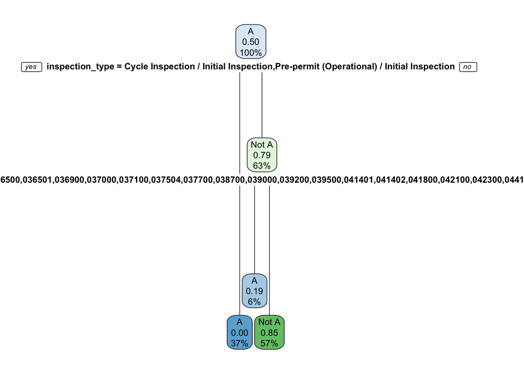

```r
set.seed(20201020)

#split the data
df_split <- initial_split(data=sampled_df,prop=0.8)
df_train <- training(df_split)
df_test <- testing(df_split)

#create a recipe
cart_rec <- recipe(formula = grade ~ ., data = df_train)%>%
  themis::step_downsample(grade)

#estimate a decision tree
cart_mod <-
  decision_tree()%>%
  set_engine(engine = "rpart")%>%
  set_mode(mode = "classification")
cart_wf <- workflow() %>%
  add_recipe(cart_rec) %>%
  add_model(cart_mod)
cart_fit <- cart_wf %>%
  fit(data = df_train)
rpart.plot::rpart.plot(x = cart_fit$fit$fit$fit)
```

## Q1-2

```r
#evaluate the model
predictions <- bind_cols(
  df_test,
  predict(object = cart_fit, new_data = df_test),
  predict(object = cart_fit, new_data = df_test, type = "prob")
)

#create a confusion matrix
conf_mat(data = predictions, truth = grade, estimate = .pred_class)
```

```
##           Truth
## Prediction    A Not A
##      A     6010    35
##      Not A 1531   948
```

```r
#calculate the precision and recall/sensitivity
metric_1 <- rbind(
  precision(data = predictions, truth = grade, estimate = .pred_class),
  recall(data = predictions, truth = grade, estimate = .pred_class)
  #put metric in one form
)
metric_1
```

```
## # A tibble: 2 × 3
##   .metric   .estimator .estimate
##   <chr>     <chr>          <dbl>
## 1 precision binary         0.994
## 2 recall    binary         0.797
```

## Q1-3

We used rpart engine and developed a decision tree for estimating a model. First, we could add auxiliary information, and thus with more features, switch to some regularized regressions, such as ridge regression, or LASSO regression. They could generate an estimation model better with more information while avoid overfitting. Second, we could make better use of current information by better feature engineering. For example, violation_code and violation_description could convert to some more general (comparing to the current violation_code) categorical variables, and may be useful to develop a new node.

## Q1-4

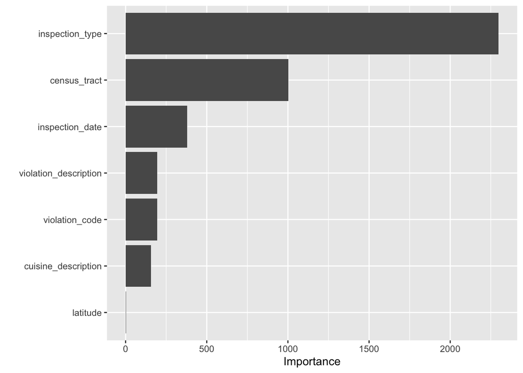

```r
cart_fit %>%
  extract_fit_parsnip() %>%
  vip(num_features = 10)
```

Vip is a package for constructing variable importance scores for many types of supervised learning algorithms. Here, we firstly use the syntax of “extract_fit_parsnip” to return our parsnip model fit. Then we use “vip()” to plot variable importance scores for the predictores in our model. By setting num_features = 10, we specified the number of variable importance scores to plot is 10. Because we use rpart engine, at each node, gini coefficient is used to pure class subsets, so here we are calculating variable importance using gini coefficient as the feature metric by:

Feature importance (FI) = Feature metric * number of instances – its left child node metric * number of instances for the left child – its right child node metric * number of instances for the right child

## Q1-5

One of ombudsman’s responsibilities at the NYC health department is to investgiate people’s complaints about the sanitary condition of restaurants. The number of complaints usually exceeds what the health department’s resources can deal with, so the ombudsman needs to decide which complaints to prioritize in investigation and which ones to postpone (or completely ignore). As new complaints come in, the ombudsman can use this model to predict the probability of that restaurant having a condition of “Not A”, and allocate resources based on the probability.

# Exercise 02

## Q2-1

```r
#convert date into useable variable
Chicago$weekday <- wday(Chicago$date, label = T)
Chicago$month <- month(Chicago$date, label = T)
Chicago$yearday <- yday(Chicago$date)

Chicago_modeling <- Chicago %>%
  slice(1:5678)
Chicago_implementation <- Chicago %>%
  slice(5679:5698) %>%
  select(-ridership)
```

## Q2-2

### a

```r
#set up a testing environment
set.seed(20211101)
chicago_split <- initial_split(data = Chicago_modeling)
chicago_train <- training(x = chicago_split)
chicago_test <- testing(x = chicago_split)
```

### b

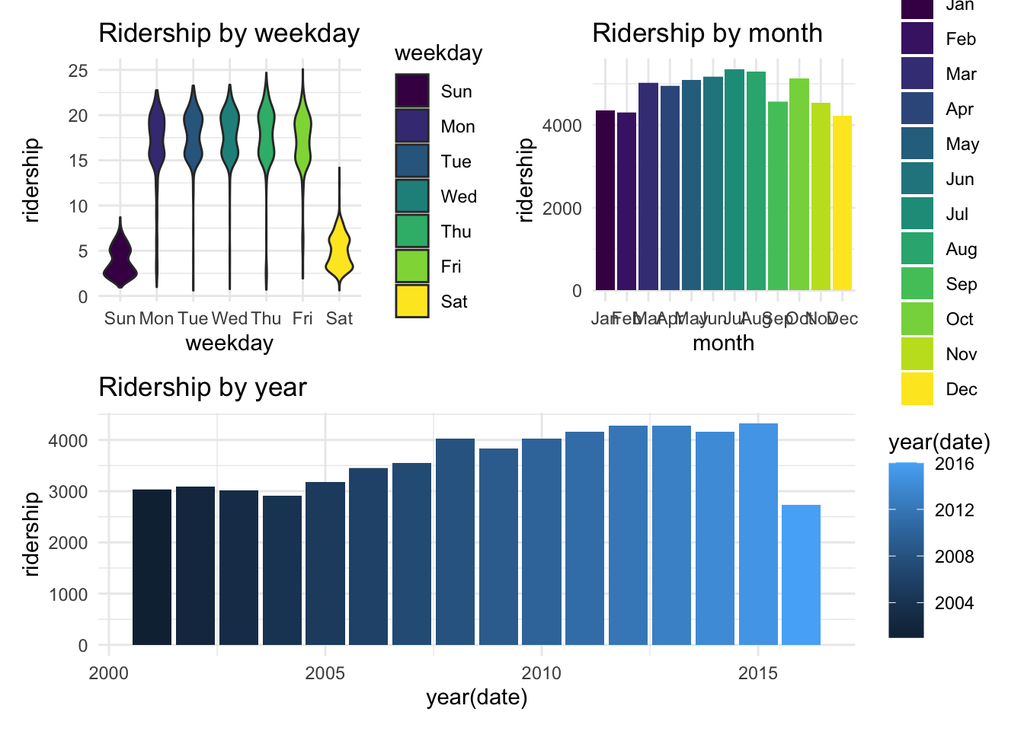

```r
#exploratory data analysis

p1 <- ggplot(chicago_train, aes(x = weekday, y = ridership, fill = weekday)) +
  geom_violin() +
  labs(title = "Ridership by weekday") +
  theme_minimal()

p2 <- ggplot(chicago_train, aes(x = month, y = ridership, fill = month)) +
  geom_bar(stat="identity") +
  labs(title = "Ridership by month") +
  theme_minimal()

p3 <- ggplot(chicago_train, aes(x = year(date), y = ridership, fill = year(date))) +
  geom_bar(stat = "identity") +
  labs(title = "Ridership by year") +
  theme_minimal()

library(patchwork)
(p1 | p2)/
  p3
```

It seems that among weekdays, the ridership is usually higher than weekend, and during summer, the ridership is usllay higher than winter.

```r
count(chicago_train, yearday)
```

```
## # A tibble: 366 × 2
##    yearday     n
##      <dbl> <int>
##  1       1    13
##  2       2    13
##  3       3    12
##  4       4    11
##  5       5    11
##  6       6    12
##  7       7    12
##  8       8    13
##  9       9    12
## 10      10    13
## # … with 356 more rows
```

### c

```r
folds <- vfold_cv(data = chicago_train, v = 10)
```

## Q2-3

### 1

```r
chicago_rec <- recipe(formula = ridership ~ ., data= chicago_train) %>%
  step_holiday(date, keep_original_cols = FALSE) %>%
  step_scale(all_numeric_predictors()) %>%
  step_center(all_numeric_predictors()) %>%
  step_unorder(month, weekday) %>%
  step_dummy(month, weekday)
```

### 2,3,4,5

lasso

```r
lasso_grid <- grid_regular(penalty(), levels = 10)

lasso_mod <- linear_reg(penalty = tune(), mixture = 1 ) %>%
  set_engine("glmnet")

lasso_wf <- workflow() %>%
  add_recipe(chicago_rec) %>%
  add_model(lasso_mod)

lasso_cv <- lasso_wf %>%
  tune_grid(
  resamples = folds,
  grid = lasso_grid
  )

lasso_best <- lasso_cv %>%
  select_best(metric = "rmse")

lasso_final <- finalize_workflow(
  lasso_wf,
  parameters = lasso_best
)

lasso_fit_rs <-
  lasso_final %>%
  fit_resamples(resamples = folds,
                metric = metric_set(rmse, mae))
collect_metrics(lasso_fit_rs)
```

```
## # A tibble: 2 × 6
##   .metric .estimator  mean     n std_err .config
##   <chr>   <chr>      <dbl> <int>   <dbl> <chr>
## 1 rmse    standard   2.12     10 0.0762  Preprocessor1_Model1
## 2 rsq     standard   0.895    10 0.00817 Preprocessor1_Model1
```

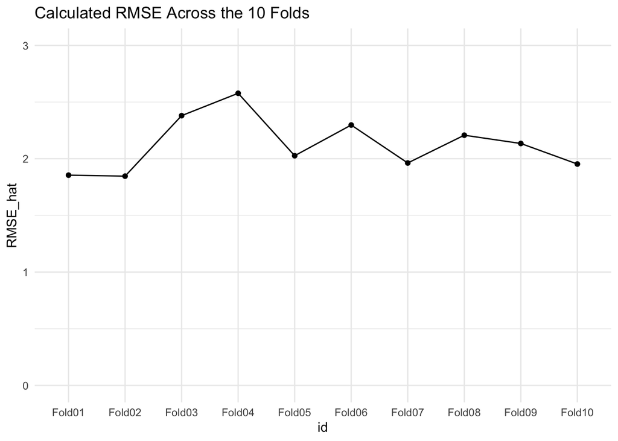

```r
collect_metrics(lasso_fit_rs, summarize = FALSE) %>%
  filter(.metric == "rmse") %>%
  ggplot(aes(id, .estimate, group = .estimator)) +
  geom_line() +
  geom_point() +
  scale_y_continuous(limits = c(0, 3)) +
  labs(title = "Calculated RMSE Across the 10 Folds", y = "RMSE_hat") +
  theme_minimal()
```

```r
#For mae, we couldn't get mae by the code above, so we extract it manually:
ctrl <- control_resamples(save_pred = TRUE)
lasso_fit_rsmae <-
  lasso_final %>%
  fit_resamples(resamples = folds,
               control = ctrl)
lasso_pred <- collect_predictions(lasso_fit_rsmae)
mae <- rbind(
  mae(filter(lasso_pred, id == "Fold01"), truth = ridership, estimate = .pred),
  mae(filter(lasso_pred, id == "Fold02"), truth = ridership, estimate = .pred),
  mae(filter(lasso_pred, id == "Fold03"), truth = ridership, estimate = .pred),
  mae(filter(lasso_pred, id == "Fold04"), truth = ridership, estimate = .pred),
  mae(filter(lasso_pred, id == "Fold05"), truth = ridership, estimate = .pred),
  mae(filter(lasso_pred, id == "Fold06"), truth = ridership, estimate = .pred),
  mae(filter(lasso_pred, id == "Fold07"), truth = ridership, estimate = .pred),
  mae(filter(lasso_pred, id == "Fold08"), truth = ridership, estimate = .pred),
  mae(filter(lasso_pred, id == "Fold09"), truth = ridership, estimate = .pred),
  mae(filter(lasso_pred, id == "Fold10"), truth = ridership, estimate = .pred)
)
mae
```

```
## # A tibble: 10 × 3
##    .metric .estimator .estimate
##    <chr>   <chr>          <dbl>
##  1 mae     standard        1.05
##  2 mae     standard        1.14
##  3 mae     standard        1.24
##  4 mae     standard        1.35
##  5 mae     standard        1.15
##  6 mae     standard        1.26
##  7 mae     standard        1.11
##  8 mae     standard        1.23
##  9 mae     standard        1.15
## 10 mae     standard        1.13
```

```r
#These are maes for each folds
```

random forest

```r
rforest_mod <- rand_forest(mode = "regression",engine = "ranger")

rforest_wf <- workflow() %>%
  add_recipe(chicago_rec) %>%
  add_model(rforest_mod)

rforest_rs <-
  rforest_wf %>%
  fit_resamples(resamples = folds)

collect_metrics(rforest_rs)
```

```
## # A tibble: 2 × 6
##   .metric .estimator  mean     n std_err .config
##   <chr>   <chr>      <dbl> <int>   <dbl> <chr>
## 1 rmse    standard   2.18     10 0.0808  Preprocessor1_Model1
## 2 rsq     standard   0.890    10 0.00827 Preprocessor1_Model1
```

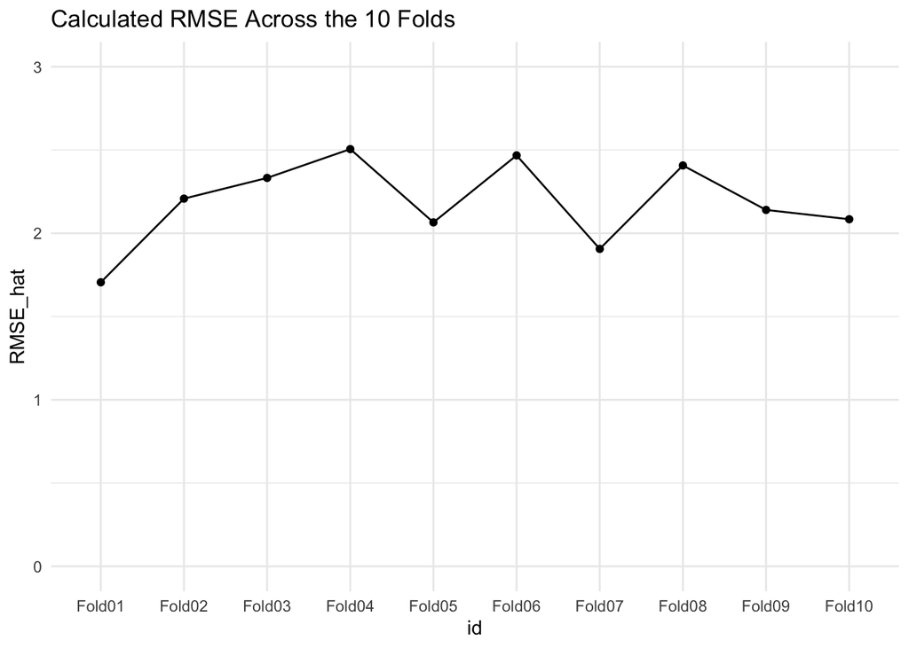

```r
collect_metrics(rforest_rs, summarize = FALSE) %>%
  filter(.metric == "rmse") %>%
  ggplot(aes(id, .estimate, group = .estimator)) +
  geom_line() +
  geom_point() +
  scale_y_continuous(limits = c(0, 3)) +
  labs(title = "Calculated RMSE Across the 10 Folds", y = "RMSE_hat") +
  theme_minimal()
```

```r
#Calculate mae
lasso_fit_rsmae <-
  lasso_final %>%
  fit_resamples(resamples = folds,
               control = ctrl)
rforest_rsmae <-
  rforest_wf %>%
  fit_resamples(resamples = folds,
                control = ctrl)
rforest_pred <- collect_predictions(rforest_rsmae)
mae2 <- rbind(
  mae(filter(rforest_pred, id == "Fold01"), truth = ridership, estimate = .pred),
  mae(filter(rforest_pred, id == "Fold02"), truth = ridership, estimate = .pred),
  mae(filter(rforest_pred, id == "Fold03"), truth = ridership, estimate = .pred),
  mae(filter(rforest_pred, id == "Fold04"), truth = ridership, estimate = .pred),
  mae(filter(rforest_pred, id == "Fold05"), truth = ridership, estimate = .pred),
  mae(filter(rforest_pred, id == "Fold06"), truth = ridership, estimate = .pred),
  mae(filter(rforest_pred, id == "Fold07"), truth = ridership, estimate = .pred),
  mae(filter(rforest_pred, id == "Fold08"), truth = ridership, estimate = .pred),
  mae(filter(rforest_pred, id == "Fold09"), truth = ridership, estimate = .pred),
  mae(filter(rforest_pred, id == "Fold10"), truth = ridership, estimate = .pred)
)
mae2
```

```
## # A tibble: 10 × 3
##    .metric .estimator .estimate
##    <chr>   <chr>          <dbl>
##  1 mae     standard       0.878
##  2 mae     standard       1.21
##  3 mae     standard       1.15
##  4 mae     standard       1.18
##  5 mae     standard       1.07
##  6 mae     standard       1.21
##  7 mae     standard       0.984
##  8 mae     standard       1.17
##  9 mae     standard       1.06
## 10 mae     standard       1.04
```

knn

```r
knn_mod <-nearest_neighbor(neighbors = 5) %>%
  set_engine(engine = "kknn") %>%
  set_mode(mode = "regression")
knn_wf <-workflow() %>%
  add_recipe(chicago_rec) %>%
  add_model(knn_mod)
knn_rs <-
  knn_wf %>%
  fit_resamples(resamples = folds)
collect_metrics(knn_rs)
```

```
## # A tibble: 2 × 6
##   .metric .estimator  mean     n std_err .config
##   <chr>   <chr>      <dbl> <int>   <dbl> <chr>
## 1 rmse    standard   2.71     10  0.0971 Preprocessor1_Model1
## 2 rsq     standard   0.831    10  0.0116 Preprocessor1_Model1
```

[figure not shown]

```r
collect_metrics(knn_rs, summarize = FALSE) %>%
  filter(.metric == "rmse") %>%
  ggplot(aes(id, .estimate, group = .estimator)) +
  geom_line() +
  geom_point() +
  scale_y_continuous(limits = c(0, 3)) +
  labs(title = "Calculated RMSE Across the 10 Folds", y = "RMSE_hat") +
  theme_minimal()
```

```r
#Calculate mae
knn_rsmae <-
  knn_wf %>%
  fit_resamples(resamples = folds,
               control = ctrl)

knn_pred <- collect_predictions(knn_rsmae)
mae3 <- rbind(
  mae(filter(knn_pred, id == "Fold01"), truth = ridership, estimate = .pred),
  mae(filter(knn_pred, id == "Fold02"), truth = ridership, estimate = .pred),
  mae(filter(knn_pred, id == "Fold03"), truth = ridership, estimate = .pred),
  mae(filter(knn_pred, id == "Fold04"), truth = ridership, estimate = .pred),
  mae(filter(knn_pred, id == "Fold05"), truth = ridership, estimate = .pred),
  mae(filter(knn_pred, id == "Fold06"), truth = ridership, estimate = .pred),
  mae(filter(knn_pred, id == "Fold07"), truth = ridership, estimate = .pred),
  mae(filter(knn_pred, id == "Fold08"), truth = ridership, estimate = .pred),
  mae(filter(knn_pred, id == "Fold09"), truth = ridership, estimate = .pred),
  mae(filter(knn_pred, id == "Fold10"), truth = ridership, estimate = .pred)
)
mae3
```

```
## # A tibble: 10 × 3
##    .metric .estimator .estimate
##    <chr>   <chr>          <dbl>
##  1 mae     standard        1.51
##  2 mae     standard        1.65
##  3 mae     standard        1.69
##  4 mae     standard        1.82
##  5 mae     standard        1.70
##  6 mae     standard        1.85
##  7 mae     standard        1.56
##  8 mae     standard        1.86
##  9 mae     standard        1.66
## 10 mae     standard        1.54
```

### 5

```r
bind_rows(
  `lasso` = show_best(lasso_fit_rs, metric = "rmse", n = 1),
  `random forest` = show_best(rforest_rs, metric = "rmse", n = 1),
  `knn` = show_best(knn_rs, metric = "rmse",n = 1),
  .id = "model"
)
```

```
## # A tibble: 3 × 7
##   model         .metric .estimator  mean     n std_err .config
##   <chr>         <chr>   <chr>      <dbl> <int>   <dbl> <chr>
## 1 lasso         rmse    standard    2.12    10  0.0762 Preprocessor1_Model1
## 2 random forest rmse    standard    2.18    10  0.0808 Preprocessor1_Model1
## 3 knn           rmse    standard    2.71    10  0.0971 Preprocessor1_Model1
```